# volcano

Pumla

2024-06-26

#Setting up environment #Clean environment

```r
rm(list = ls(all.names = TRUE))
gc()
```

```
##          used (Mb) gc trigger (Mb) max used (Mb)
## Ncells 523953 28.0    1166815 62.4   660385 35.3
## Vcells 950271  7.3    8388608 64.0  1769772 13.6
```

#Load libraries

```r
library(edgeR)
```

```r
library(pheatmap)
library(dplyr)
library(ggplot2)
library(ggrepel)
```

#Set the working directory

```r
setwd("~/starmm/volcano")
```

#Load count data

```r
count_data <- read.csv('Counts.csv', header = TRUE, row.names = 1)
```

#Load sample information

```r
sample_info <- read.csv('DesignV.csv', header = TRUE, row.names = 1)
```

#Set up the DGEList object

```r
dge <- DGEList(counts = count_data, group = sample_info$Treatment)
```

#Filter lowly expressed genes

```r
keep <- rowSums(cpm(dge) > 1) >= 1
dge <- dge[keep,]
```

#Estimate dispersion

```r
dge <- estimateGLMCommonDisp(dge)
dge <- estimateGLMTrendedDisp(dge)
dge <- estimateGLMTagwiseDisp(dge)
```

#Perform differential expression analysis

```r
fit <- glmQLFit(dge)
qlf <- glmQLFTest(fit, coef = 2)
```

#Extract results

```r
edger_result <- topTags(qlf, n = nrow(dge))
```

#Save the edgeR result

```r
write.table(edger_result$table, "edger_results.csv", sep = ",", col.names = NA)
```

#Read in the CSV file

```r
edger_results <- read.csv("edger_results.csv")
```

#Rename the first column from “X” to “ensembl_gene_id”

```r
colnames(edger_results)[1] <- "ensembl_gene_id"
```

#Check the column names to confirm the change

```r
colnames(edger_results)
```

```
## [1] "ensembl_gene_id" "logFC"           "logCPM"          "F"
## [5] "PValue"          "FDR"
```

#checking to make sure both file have Gene id as first column

```r
colnames(edger_results)
```

```
## [1] "ensembl_gene_id" "logFC"           "logCPM"          "F"
## [5] "PValue"          "FDR"
```

#Function to remove versioned part from Ensembl gene IDs

```r
remove_version <- function(gene_ids) {
  pattern <- "^(\\w+)\\.\\d+$"  # Regular expression to match the part before the dot
  unversioned_ids <- sub(pattern, "\\1", gene_ids)  # Extract the part before the dot
  return(unversioned_ids)  # Return the unversioned gene IDs
}
```

#Apply the function to the ensembl_gene_id column in edger_results

```r
edger_results$ensembl_gene_id <- remove_version(edger_results$ensembl_gene_id)
```

#checking to make sure both file have Gene id as first column

```r
colnames(edger_results)
```

```
## [1] "ensembl_gene_id" "logFC"           "logCPM"          "F"
## [5] "PValue"          "FDR"
```

#now i want to assign gene names and gene type to my data set #Load biomaRt library

```r
library(biomaRt)
```

#Use Ensembl biomart for mouse

```r
ensembl <- useEnsembl(biomart = "ensembl", dataset = "mmusculus_gene_ensembl")  # for mouse
```

#Specify attributes to retrieve

```r
attributes <- c("ensembl_gene_id", "external_gene_name", "description")
```

#Retrieve gene information for mouse

```r
gene_info_mouse <- getBM(attributes = attributes, mart = ensembl)
```

#Write the gene_mapping_table to a CSV file

```r
write.csv(gene_info_mouse, file = "gene_info_mouse.csv", row.names = FALSE)
```

```r
colnames(edger_results)
```

```
## [1] "ensembl_gene_id" "logFC"           "logCPM"          "F"
## [5] "PValue"          "FDR"
```

```r
colnames(gene_info_mouse)
```

```
## [1] "ensembl_gene_id"    "external_gene_name" "description"
```

#Assuming edger_results and gene_info_mouse dataframes are available

#Merge based on ensembl_gene_id

```r
merged_data <- merge(edger_results, gene_info_mouse, by = "ensembl_gene_id")
```

#Write the merged data to a CSV file

```r
write.csv(merged_data, file = "merged_data.csv", row.names = FALSE)
```

```r
colnames(merged_data)
```

```
## [1] "ensembl_gene_id"    "logFC"              "logCPM"
## [4] "F"                  "PValue"             "FDR"
## [7] "external_gene_name" "description"
```

#Sort merged_data by absolute log fold change (descending order)

```r
merged_data <- merged_data %>%
  arrange(desc(abs(logFC)))
```

#Select the top 10 most differentially expressed genes

```r
top_10_genes <- head(merged_data, 10)
```

#Create Volcano Plot

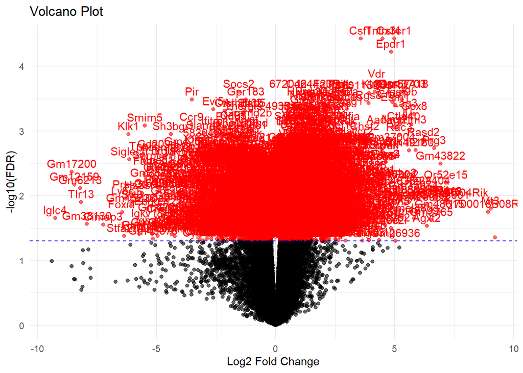

```r
plot(ggplot(merged_data, aes(x = logFC, y = -log10(FDR))) +
       geom_point(color = ifelse(merged_data$FDR < 0.05, "red", "black"), alpha = 0.6) +
       geom_hline(yintercept = -log10(0.05), linetype = "dashed", color = "blue") +
       labs(x = "Log2 Fold Change", y = "-log10(FDR)", title = "Volcano Plot") +
       theme_minimal() +
       geom_text(data = filter(merged_data, FDR < 0.05), aes(label = external_gene_name), vjust = -0.5, color = "red"))
```

#Filter significant genes

```r
significant_genes <- merged_data %>% filter(FDR < 0.05)
```

#Select top 10 significant genes

```r
top_10_significant_genes <- head(significant_genes, 10)
```

#Create Volcano Plot

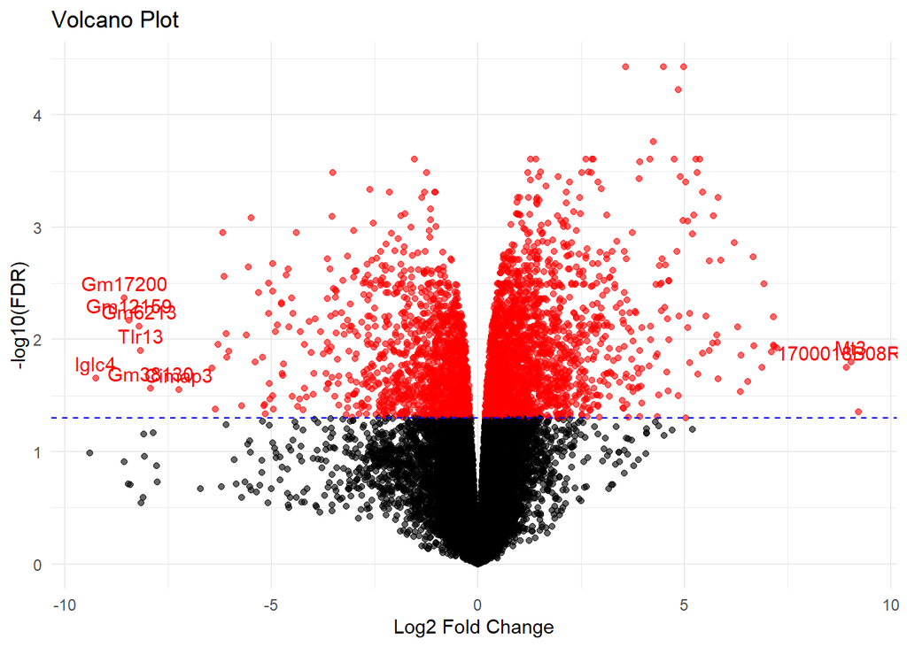

```r
plot(ggplot(merged_data, aes(x = logFC, y = -log10(FDR))) +
       geom_point(color = ifelse(merged_data$FDR < 0.05, "red", "black"), alpha = 0.6) +
       geom_hline(yintercept = -log10(0.05), linetype = "dashed", color = "blue") +
       geom_text(data = top_10_significant_genes, aes(label = external_gene_name), vjust = -0.5, color = "red") +
       labs(x = "Log2 Fold Change", y = "-log10(FDR)", title = "Volcano Plot") +
       theme_minimal())
```

#Select top 5 significant genes

```r
top_5_significant_genes <- head(significant_genes, 5)
```

#Create Volcano Plot for Top 5 Significant Genes

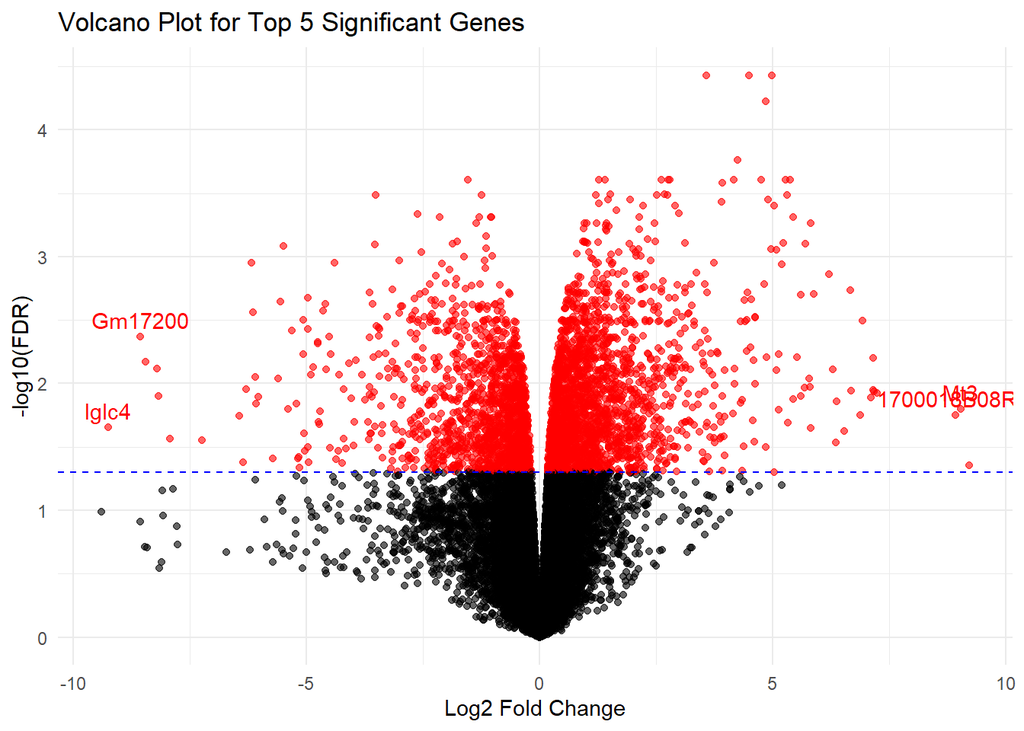

```r
plot(ggplot(merged_data, aes(x = logFC, y = -log10(FDR))) +
       geom_point(color = ifelse(merged_data$FDR < 0.05, "red", "black"), alpha = 0.6) +
       geom_hline(yintercept = -log10(0.05), linetype = "dashed", color = "blue") +
       geom_text(data = top_5_significant_genes, aes(label = external_gene_name), vjust = -0.5, color = "red") +
       labs(x = "Log2 Fold Change", y = "-log10(FDR)", title = "Volcano Plot for Top 5 Significant Genes") +
       theme_minimal())
```